# ETC5521 Exploratory data analysis: Assignment 2

INSTRUCTIONS AND SOLUTIONS ARE NOT TO BE SHARED

Author

Prof. Di Cook

Published

August 30, 2023

## 🎯 Goal

The assignment is designed to assess your knowledge of inference for exploratory data analysis, and making summaries of univariate and bivariate, and interpretation of them. The assignment represents 25% of your final grade for ETC5521. This is an **individual** assignment.

## 🔧 Preparation

1. Accept the GitHub Classroom Assignment [here](https://classroom.github.com/a/IetTLhMI) using a GitHub Classroom compatible web browser (e.g. Chrome or Firefox; Safari gets stuck when accepting the assignment so do not use Safari). This should generate a **private** GitHub repository that can be found at https://github.com/etc5521-2023. Your GitHub assignment 2 repo should contain the file `assign02.html`, `README.md`, `Q1.qmd`, `Q2.qmd`, `Q3.qmd`, `Q4.qmd`, `Q5.qmd`, `aus_brazil.rda`, `movies_2023.rda`, `TB_data_dictionary_2023-08-21.csv`, `TB_notifications_2023-08-21.csv`, `viewports.csv`, `etc5521-assignment2.Rproj`, `AI_script.md` and `.gitignore`.
2. Answer each question in the corresponding `qmd` in the repo, e.g. for Question 1 write your answer in Q1.
3. For the final submission knit each of the `.qmd` files and push the resulting `.html` files to your GitHub repo. You will also need to **upload the script of any Generative AI conversation** you employed in arriving at your solution. *Note that marks are allocated for overall grammar and structure of your final report.*
4. We will check your git commit history. You should have contributions to the repo with consistent commits over time.
5. Refer back to relevant lecture notes and tutorial exercises in developing your solutions. You are expected to **develop your solutions by yourself**, without discussing any details with other class members or other friends or contacts. You can ask for clarifications from the teaching team and we encourage you to attend consultations to get assistance as needed. As a Monash student you are expected to adhere to **[Monash’s academic integrity policy](https://publicpolicydms.monash.edu/Monash/documents/1935748).** and the details on use of Generative AI as detailed on this unit’s Moodle assessment overview.

Deadlines:

| Due date | Turn in | Points |
| --- | --- | --- |
| 4:30pm Fri Sep 1 | Assignment 2 Repo on GitHub has been created | 2 |
| 4:30pm Fri Sep 8 | At least three substantial commits to your Assignment 2 Repo, deomstrating that at least 20% of assignment has been solved | 3 |
| 4:30pm Fri Sep 15 | Final solutions available on repo | 95 |

## 💻 Exercises

1. Data from a recent study of viewports can be found in the data set `viewports.csv`. The purpose of the data collection was to *you simply do not know how users are going to visit your website or web app. Instead of making design decisions on strict, limited breakpoints, keep in mind the sheer amount of fragmentation there is in viewports.* The data was collected primarily from the USA and Europe, on 122,321 devices. Below is a glimpse of the data. It has three columns defining the width and height of the screen, and count is the number of devices with these dimensions.

```
Rows: 2,291
Columns: 3
$ Width  <dbl> 390, 393, 375, 390, 393, 414, 375, 428, 375, 375, 430, 412, 390…
$ Height <dbl> 670, 666, 635, 664, 660, 721, 641, 752, 559, 629, 746, 783, 663…
$ Count  <dbl> 8691, 4800, 4618, 2503, 2318, 2130, 1890, 1692, 1643, 1393, 123…
```

1. How many variables in this data and what type are they?
2. Based on the description above, and the variables available in the data, posit two open-ended questions that might be interesting to answer with the data.
3. Create a bubble scatterplot, where size represents the count, with an `x=y` guideline underlying the points. Describe what you learn about viewport sizes from this plot.
4. Make a transformation of the data to create a new variable, `aspect_ratio`, based on Width and Height, that will allow you to explain the sizes in one of the conventional terms eg 16:9. (Note: use width:height definition of aspect ratio.)
5. Show the aspect ratio as a density plot, where the x axis labels correspond to particular ratios, “1:3”, “9:16”, “1:1”, “16:9”, “3:1”. (Note: Remember that the data is aggregated already, so that Count needs to the incorporated into computing the density. Setting the axis limits to between 0 and 4 is helpful, too.) Describe the distribution and explain what you learn.
6. What is the most frequent aspect ratio? What (type of) device does this correspond to? (Note: You’ll need to do some web searching.)
2. The term “Barbenheimer” began on social media before the simultaneous theatrical release of two blockbuster films, Barbie and Oppenheimer, on July 21, 2023. This question asks you to explore data on movies released in 2023, not just these two. The data was compiled from https://datasets.imdbws.com and is available for you in the file “movies_2023.rda”. (For each of the plots in d, e, f mark where Barbie and Oppenheimer fall, just for fun, and extra discussion points.)
1. How many movies and variables are in the data?
2. Think about your expectations. Write these down before you make any computations or plots of the data.
- What genre keywords would you expect to be the most common?
- What would you expect the relationship between number of votes and ratings to be?
- What do you think the relationship between genre keyword and ratings might be? (What genre would have the top rating and which would have the lowest?)
- Would you expect a relationship between run time and rating to be?
3. Make a bar chart of the genre key words (`adventure` to `western`), and summarise the distribution.
4. Plot the average rating by genre, in the best way that you can. Describe the distribution, and what you learn about ratings and genre.
5. Plot ratings and number of votes, being careful as to which axis each should be plotted on. Summarise the distribution and what you learn.
6. Make appropriate plots to explore the relationship of run time against ratings.
3. The World Health Organisation (WHO) routinely reports statistics on tuberculosis. WHO says: “Every year, 10 million people fall ill with tuberculosis (TB). Despite being a preventable and curable disease, 1.5 million people die from TB each year – making it the world’s top infectious killer.” This question is about the statistics reported by WHO on TB notifications.

The data and dictionary were downloaded from https://www.who.int/teams/global-tuberculosis-programme/data. We have made them available in the template repo.

1. How many countries are recorded?
2. What is the earliest and latest years in the data?
3. There are numerous ways that TB is detected, and this is reflected in the data as `new_sp`, `new_sn`, `new_su`, `new_ep` and `new_oth`. Create a new variable which sums these values for each year, for each country. Make an appropriate plot to show the counts for Australia over time. Describe the pattern, and try to explain it, which might require searching for more information about TB reporting.
4. Subset the data to Australia and five of it’s nearest neighbours (Fiji, Indonesia, New Zealand, Papua New Guinea, and East Timor). Make an appropriate plot to compare the incidence across countries.
5. What is wrong with directly comparing the incidence? What information is missing in order to make the comparison. Without adding new data, come up with a transformation of counts that will fix the problem. Make a new plot, and describe how TB is occurring similarly or differently in Australia and it’s nearest neighbours.
4. A very successful 2023 Women’s World Cup soccer was held in Australia and New Zealand in the last two months. Data from the last one held in 2019 can be downloaded from R using the package `StatsBombR`. The data for the Australia vs Brazil match have been downloaded and processed and made available in the file `aus_brazil.rda`. The match was played on June 14, 2019, in Stade de la Mosson, in France, and Australia won 3-2. This question explores the match data. It will help if you install these packages:

```r
remotes::install_github("statsbomb/SDMTools")
remotes::install_github("statsbomb/StatsBombR")
devtools::install_github("FCrSTATS/SBpitch")
```

A really nice introduction to working with the data is available [here](https://statsbomb.com/wp-content/uploads/2022/08/Working-with-R.pdf).

1. Make a plot of shots on goal made by each team that looks like the following, and include your cleanly written code. (Note: 1. `location` has the position from which passes were made, in the form of an array. You can access the x and y values using `location.x` and `location.y`. 2. The positions have been processed so both teams are playing from left to right, so that it is easy to compare their play.)

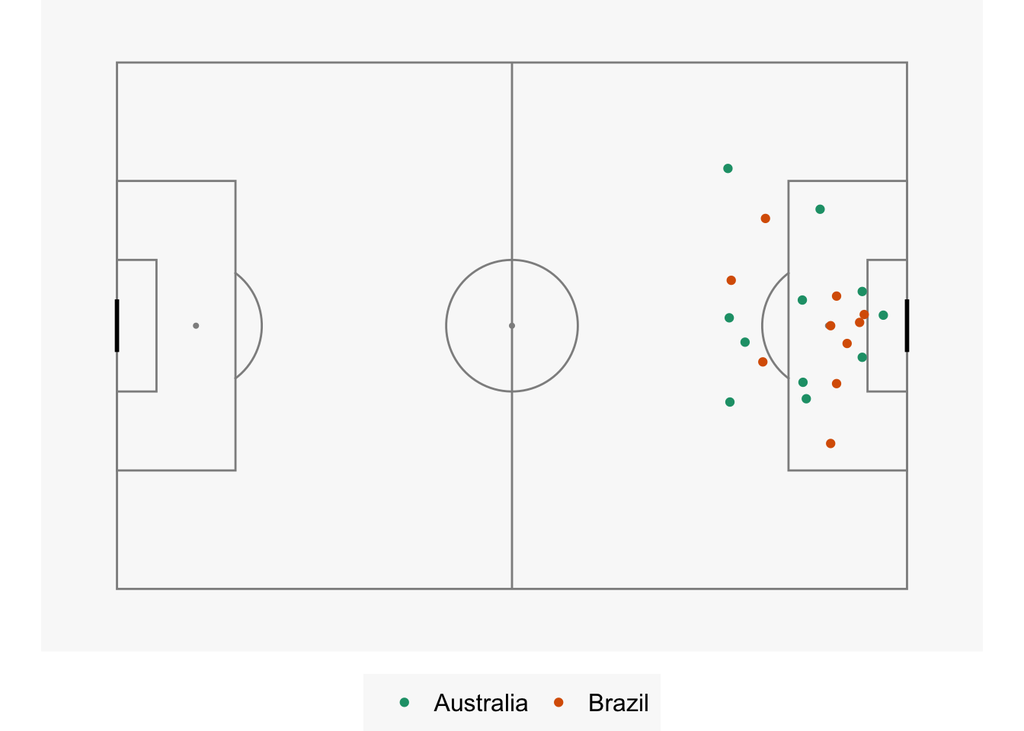

2. Summarise the shots for each country by player. Would you say that shots were a team effort or dominated by certain players?
3. Now let’s take a look at passes. The location from which passes are made could be characteristic of a team. Make a lineup to test whether the position from which a pass was made was different between Australia and Brazil. Conduct a visual inference analysis to determine if the actual plot can be distinguished from the null plots. Report your $p$-value, after asking 8 of your friends to judge your lineup, and summarise your findings.
4. The type of passes can also be characteristic of a team’s play. Explore this with the variable `pass.length`, using a visual inference analysis.
5. For each of the following code fragments, write down was a potentially useful null hypothesis and null generating mechanism would be.
1. `cl` is categorical and `x1` is numeric.

```
ggplot(data) +
  geom_boxplot(aes(x=cl, y=x1))
```

2. `temp` is the temperature of stars and is thought to have a skewed distribution.

```
ggplot(stars, aes(temp)) +
  geom_histogram()
```

3. `rooms` is an integer variable, `perc` is a percentage (or count/frequency), `miss` is a logical variable indicating the value was missing or not.

```
ggplot(housing, aes(x=rooms, y=perc, fill = miss)) +
  geom_col(position = "dodge")
```

4. `height` and `weight` are quantitative variables, `sport` is categorical.

```
ggplot(olympics, aes(x = height,
                     y = weight,
                     colour = sport)
      ) +
  geom_smooth(method = "lm", se = FALSE)
```

5. `.resid` are residuals from a linear model fit.

```
ggplot(housing, aes(sample = .resid)) +
    geom_qq() +
    geom_qq_line()
```

## 🧠 Generative AI analysis

In this part, we would like you to actively discuss how generative AI helped with your answers to the assignment questions, and where or how it was mistaken or misleading.

You need to provide the full script of your conversation with any generative AI tool. You do not need to use a paid service, as the freely available systems will also be helpful.

## 📝 Marks

| Part | Points |
| --- | --- |
| GitHub Repo | 5 |
| Q1-Q5 each worth | 15 |
| Generative AI Analysis | 10 |
| Formatting, Spelling & Grammar | 10 |